# Intro to Environmental Data Science in R

Caitlin Mothes - Devin Hunt 2023-01-23

## Before this Lesson…

Before this lesson you must complete all set up instructions found [here](https://github.com/Data-Sci-Intro-2023#required-to-do-before-the-class-starts) and watch the instructional videos for this week:[Day 1 R Git and GitHub Intro](https://youtu.be/l3-xEn1KQxY) and [Day 2 Spatial Intro](https://youtu.be/T3M40tbbFwg).

## 1. Getting to know RStudio

When you first open RStudio, it is split into 3 panels:

- **The Console** (left), where you can directly type and run code (by hitting Enter)
- **The Environment/History pane** (upper-right), where you can view the objects you currently have stored in your environment and a history of the code you’ve run
- **The Files/Plots/Packages/Help pane** (lower-right), where you can search for files, view and save your plots, view and manage what packages are loaded in your library and session, and get R help

[figure not shown]

Image Credit: Software Carpentry

To write and save code you use scripts. You can open a new script with File -> New File or by clicking the icon with the green plus sign in the upper left corner. When you open a script, RStudio then opens a fourth **‘Source’ panel** in the upper-left to write and save your code. You can also send code from a script directly to the console to execute it by highlighting the **entire** code line/chunk (or place your cursor at the end of the code chunk) and hit CTRL+ENTER on a PC or CMD+ENTER on a Mac.

[figure not shown]

Image Credit: Software Carpentry

It is good practice to add comments/notes throughout your scripts to document what the code is doing. To do this start a line with a `#`. R knows to ignore everything after a `#`, so you can write whatever you want there. Note that R reads line by line, so if you want your comments to carry over multiple lines you need a `#` at every line.

## 2. Version Control with Git and GitHub

From this week’s [instructional video](https://youtu.be/l3-xEn1KQxY) and [set up instructions/tutorials](https://happygitwithr.com/github-acct.html) you learned some of the basics of working in Git, GitHub and connecting Git to your R environment.

For today’s lesson, you are going to work through creating a Git repository, linking it to an RStudio Project, working through some R fundamentals, and pushing your code to your Git repo.

### 2.1 Create a Git Repo

First step, go to your GitHub account and create a new repository, let’s call it “GitHub-R-intro”. Remember naming conventions are important. A common convention is to use dashes between words like we did here. You could also use underscores (“_”) or camelCase naming conventions.

Now we are going to clone this repo to our local machines so you can work in them, write code, and push changes to GitHub.

We are going to use the terminal within RStudio to talk to GitHub.

First Open RStudio, then go to Tools -> Global Options -> Terminal and make sure ‘Git Bash’ is selected for ‘New terminals open with:’.

Now we can set up an R Project that is connected to our Git repo and start coding!

## 3. R Projects

As a first step whenever you start a new project, workflow, analysis, etc., it is good practice to set up an R project. R Projects are RStudio’s way of bundling together all your files for a specific project, such as data, scripts, results, figures. Your project directory also becomes your working directory, so everything is self-contained and easily portable.

Throughout the course you will be cloning repositories on GitHub where we may already have an R project set up (you can tell by checking if there is a .Rproj file in the directory/repo with the same name as the repo), but here we are going to walk through how to set up your own projects.

You can start an R project in an existing directory or in a new one. To create a project go to File -> New Project:

[figure not shown]

To make sure our R Project is talking to our Git repo, we choose ‘Existing Directory’ and choose your Git repo directory you just cloned to your local machine. Before creating the project, make sure to check ‘Open in a new session’.

*Note: Another way you can link an R Project to GitHub is instead of cloning it via the Git terminal, you can start with creating an R Project and at this step choose ‘Version Control’ and then paste the HTTPS link from the repo.*

Now we are working in our R project that is connected to our Git repo. You can see the working directory printed at the top of your console is now our project directory, and in the ‘Files’ tab in RStudio you can see we have an .Rproj file, which will open up this R project in RStudio whenever you come back to it. **For example close out of this R session, navigate to the project folder on your computer, and double-click the .Rproj file.**

We also know it is connected to our repo by the existence of the ‘Git’ tab in the upper right pane. We will be teaching you all how to commit and push changes to GitHub via the Terminal, but this Git tab acts as a GUI for pushing changes that you may want to use in the future. I personally like to keep the Git tab open to have a present view of all my modified/untracked files I need to be sure to push at the end of the day.

## 4. Write a set-up script

Let’s start coding!

The first thing you do in a fresh R session is set up your environment, which mostly includes installing and loading necessary libraries and reading in required data sets. Let’s open a fresh R script and save it in our root (project) directory. Call this script ‘setup.R’.

### 4.1 Functions

Before creating a set up script, it might be helpful to understand the use of functions in R if you are new to this programming language. R has many built in functions to perform various tasks. To run these functions you type the function name followed by parentheses. Within the parentheses you put in your specific arguments needed to run the function.

```r
# mathematical functions with numbers
log(10)

# average a range of numbers
mean(1:5)

# nested functions for a string of numbers, using the concatenate function 'c'
mean(c(1,2,3,4,5))


# functions with characters
print("Hello World")

paste("Hello", "World", sep = "-")
```

### 4.2 Packages

R Packages include reusable functions that are not built-in with R. To use these functions, you must install the package to your local system with the `install.packages()` function. Once a package is installed on your computer you don’t need to install it again. Anytime you want to use the package in a new R session you load it with the `library()` function.

**When do I use** `::` ?

If you have a package installed, you don’t necessarily have to load it in with `library()` to use it in your R session. Instead you can type the package name followed by `::` and use any functions in that package. This may be useful for some one-off functions using a specific package, however if you will be using packages a lot throughout your workflow you will want to load it in to your session. You should also use `::` in cases where you have multiple packages loaded that may have conflicting functions (e.g., `plot()` in Base R vs. `plot()` in the `terra` package).

#### 4.2.1 Base R vs. The Tidyverse

You may hear us use the terms ‘Base R’ and ‘Tidyverse’ a lot throughout this course. Base R includes functions that are installed with the R software and do not require the installation of additional packages to use them. The Tidyverse is a collection of R packages designed for data manipulation, exploration, and visualization that you are likely to use in every day data analysis, and all use the same design philosophy, grammar, and data structures. When you install the Tidyverse, it installs all of these packages, and you can then load all of them in your R session with `library(tidyverse)`. Base R and Tidyverse have many similar functions, but many prefer the style, efficiency and functionality of the Tidyverse packages, and we will mostly be sticking to Tidyverse functions for this course.

#### 4.2.2 Package load function

To make code reproducible (meaning anyone can run your code from their local machines) we can write a function that checks whether or not necessary packages are installed, if not install them and load them, or if they are already installed it will only load them and not re-install. This function looks like:

```r
packageLoad <-
  function(x) {
    for (i in 1:length(x)) {
      if (!x[i] %in% installed.packages()) {
        install.packages(x[i])
      }
      library(x[i], character.only = TRUE)
    }
  }
```

For each package name given (‘x’) it checks if it is already installed, if not installs it, and then loads that package into the session. In Week 3 you will learn more about writing custom functions, but for now you can copy/paste this function and put it at the top of your set up script. When you execute this chunk of code, you won’t see anything printed in the console, however you should now see `packageLoad()` in your Environment under ‘Functions’. You can now use this function as many times as you want. Test is out, and use it to install the `tidyverse` package(s).

```r
packageLoad('tidyverse')
```

You can also give this function a string of package names. Lets install all the packages we will need for the first week (and beyond). We will discuss these packages more later on.

```r
# create a string of package names
packages <- c('tidyverse',
              'palmerpenguins',
              'sf',
              'rmarkdown',
              'tigris',
              'elevatr',
              'rgdal')

packageLoad(packages)
```

Since this is code you will be re-using throughout your workflows, we will save it as its own script and run it at the beginning of other scripts/documents using the `source()` function.

## 5. R Markdown

Throughout this course you will be working mostly in R Markdown documents. R Markdown is a notebook style interface integrating text and code, allowing you to create fully reproducible documents and render them to various elegantly formatted static or dynamic outputs.

You can learn more about R Markdown at their website, which has really informative lessons on their [Getting Started](https://rmarkdown.rstudio.com/lesson-1.html) page and see the range of outputs you can create at their [Gallery](https://rmarkdown.rstudio.com/gallery.html) page.

### 5.1 What About Quarto?

Some of you may have heard of Quarto, which is essentially an extension of R Markdown but it lives as its own software to allow its use in other languages such as Python, Julia and Observable. You can install the Quarto CLI on its own and RStudio will detect it so you can create documents within the IDE, or alternatively with newer versions of RStudio a version of Quarto is built-in and you can enable Quarto through the R Markdown tab in Global Options. R Markdown isn’t going anywhere, however many in the data science realm are switching to Quarto. Quarto documents are very similar to R Markdown, in fact Quarto can even render R Markdown documents, so after learning R Markdown in this course you should have some of the fundamental skills to easily switch to Quarto if you want to. You can read more about Quarto [here](https://quarto.org/).

### 5.2 Getting started with R Markdown

Let’s create a new document by going to File -> New File -> R Markdown. You will be prompted to add information like title and author, fill those in (let’s call it “Intro to R and R Markdown”) and keep the output as HTML for now. Click OK to create the document.

This creates an outline of an R Markdown document, and you see the title, author and date you gave the prompt at the top of the document which is called the YAML header.

Notice that the file contains three types of content:

- An (optional) YAML header surrounded by `---`s
- R code chunks surrounded by `` ``` ``s
- text mixed with simple text formatting

Since this is a notebook style document, you run the code chunks by clicking the green play button, and then the output is returned directly below the chunk.

When you want to create a report from your notebook, you render it by hitting the ‘knit’ button, and it will render to the format you have specified in the YAML header. In order to do so though, you need to have the `rmarkdown` package installed.

You can delete the rest of the code/text below the YAML header, and insert a new code chunk at the top. You can insert code chunks by clicking the green C with the ‘+’ sign at the top of the source editor, or with the keyboard short cut (Ctrl+Alt+I for Windows, Option+Command+I for Macs). For the rest of the lesson (and course) you will be writing and executing code through code chunks, and you can type any notes in the main body of the document.

The first chunk is almost always your set up code, where you read in libraries and any necessary data sets. Here we will execute our set up script to install and load all the libraries we need:

```r
source("setup.R")
```

[output not shown]

## 6. Explore

Normally when working with a new data set, the first thing we do is explore the data to better understand what we’re working with. To do so, you also need to understand the fundamental data types and structures you can work with in R.

### 6.1 The `penguins` data

For this intro lesson, we are going to use the Palmer Penguins data set (which is loaded with the `palmerpenguins` package you installed in your set up script). This data was collected and made available by [Dr. Kristen Gorman](https://www.uaf.edu/cfos/people/faculty/detail/kristen-gorman.php) and the [Palmer Station, Antarctica LTER](https://pallter.marine.rutgers.edu/), a member of the [Long Term Ecological Research Network](https://lternet.edu/).

Load the `penguins` data set.

```r
data("penguins")
```

You now see it in the Environment pane. Print it to the console to see a snapshot of the data:

```r
penguins
```

### 6.2 Data Types

This data is structured is a data frame, probably the most common data type and one you are most familiar with. These are like Excel spreadsheets, tabular data organized by rows and columns. However we see at the top this is called a `tibble` which is just a fancy kind of data frame specific to the `tidyverse`.

At the top we can see the data type of each column. There are five main data types:

- **character**: `"a"`, `"swc"`
- **numeric**: `2`, `15.5`
- **integer**: `2L` (the `L` tells R to store this as an integer)
- **logical**: `TRUE`, `FALSE`
- **complex**: `1+4i` (complex numbers with real and imaginary parts)

Data types are combined to form data structures. R’s basic data structures include

- atomic vector
- list
- matrix
- data frame
- factors

You can see the data type or structure of an object using the `class()` function, and get more specific details using the `str()` function. (Note that ‘tbl’ stands for tibble).

```r
class(penguins)
str(penguins)
```

```r
class(penguins$species)
str(penguins$species)
```

When we pull one column from a data frame like we just did above using the `$` operator, that returns a vector. Vectors are 1-dimensional, and must contain data of a single data type (i.e., you cannot have a vector of both numbers and characters).

If you want a 1-dimensional object that holds mixed data types and structures, that would be a list. You can put together pretty much anything in a list.

```r
myList <- list("apple", 1993, FALSE, penguins)
str(myList)
```

You can even nest lists within lists

```r
list(myList, list("more stuff here", list("and more")))
```

You can use the `names()` function to retrieve or assign names to list and vector elements

```r
names(myList) <- c("fruit", "year", "logic", "data")
names(myList)
```

### 6.3 Indexing

Indexing is an extremely important aspect to data exploration and manipulation. In fact you already started indexing when we looked at the data type of individual columns with `penguins$species`. How you index is dependent on the data structure.

Index lists:

```r
# for lists we use double brackes [[]]
myList[[1]]

myList[["data"]]
```

Index vectors:

```r
# for vectors we use single brackets []
myVector <- c("apple", "banana", "pear")
myVector[2]
```

Index data frames:

```r
# dataframe[row(s), columns()]
penguins[1:5, 2]

penguins[1:5, "island"]

penguins[1, 1:5]

penguins[1:5, c("species","sex")]

penguins[penguins$sex=='female',]

# $ for a single column
penguins$species
```

#### 6.3.1 Exercises

1. Why don’t the following lines of code work? Tweak each one so the code runs

```r
myList[["fruit"]]
```

```r
penguins$flipper_length_mm
```

[output not shown]

```r
penguins[penguins$island == "Dream", ]
```

```
## # A tibble: 124 × 8
##    species island bill_length_mm bill_depth_mm flipper_len…¹ body_…² sex    year
##    <fct>   <fct>           <dbl>         <dbl>         <int>   <int> <fct> <int>
##  1 Adelie  Dream            39.5          16.7           178    3250 fema…  2007
##  2 Adelie  Dream            37.2          18.1           178    3900 male   2007
##  3 Adelie  Dream            39.5          17.8           188    3300 fema…  2007
##  4 Adelie  Dream            40.9          18.9           184    3900 male   2007
##  5 Adelie  Dream            36.4          17             195    3325 fema…  2007
##  6 Adelie  Dream            39.2          21.1           196    4150 male   2007
##  7 Adelie  Dream            38.8          20             190    3950 male   2007
##  8 Adelie  Dream            42.2          18.5           180    3550 fema…  2007
##  9 Adelie  Dream            37.6          19.3           181    3300 fema…  2007
## 10 Adelie  Dream            39.8          19.1           184    4650 male   2007
## # … with 114 more rows, and abbreviated variable names ¹flipper_length_mm,
## #   ²body_mass_g
```

2. How many species are in the `penguins` dataset? What islands were the data collected for? (Note: the `unique()` function might help)

```r
length(unique(penguins$species))
```

```
## [1] 3
```

3. Use indexing to create a new data frame that has only 3 columns: species, island and flipper length columns, and subset all rows for just the ‘Dream’ island.

```r
penguins_subset <- penguins[, c(1, 2, 5)]

penguins_dream <- penguins_subset[penguins_subset$island == "Dream", ]

  # as.data.frame(penguins$species penguins[penguins$island == "Dream", ] penguins$flipper_length_mm))
```

4. Use indexing and the `mean()` function to find the average flipper length for the *Adelie* species on Dream island. (Note: explore the `mean()` function and how to deal with NA values).

```r
mean(penguins_dream$flipper_length_mm[penguins_dream$species == "Adelie"], na.rm = TRUE)
```

```
## [1] 189.7321
```

### 6.4 The `dplyr` package

So far the code you’ve been writing has consisted of Base R functionality. Now lets dive into the Tidyverse with the `dplyr` package.

`dplyr` is a Tidyverse package to handle most of your data exploration and manipulation tasks. Now that you have learned indexing, you may notice the first two `dplyr` functions you are going to learn, `filter()` and `select()` act as indexing functions by subsetting rows and columns based on specified names and/or conditions.

**Subset rows with [`filter()`](https://dplyr.tidyverse.org/reference/filter.html)**

You can filter data in many ways using logical operators (`>`, `>=`, `<`, `<=`, `!=` (not equal), and `==` (equal)), AND (`&`), OR (`|`), and NOT (`!`) operators, and other operations such as `%in%`, which returns everything that matches at least one of the values in a given vector, and `is.na()` and `!is.na()` to return all missing or all non-missing data.

```r
filter(penguins, species == "Adelie")

filter(penguins, species != "Adelie")

filter(penguins, island %in% c("Dream", "Torgersen") & !is.na(bill_length_mm))
```

**Note: Tidyverse package functions take in column names *without* quotations.**

Using `dplyr` functions will not manipulate the original data, so if you want to save the returned object you need to assign it to a new variable.

**Select columns with [`select()`](https://dplyr.tidyverse.org/reference/select.html)**

`select()` has many helper functions you can use with it, such as `starts_with()`, `ends_with()`, `contains()` and many more that are very useful when dealing with large data sets. See `?select` for more details

```r
# Select two specific variables
select(penguins, species, sex)

# Select a range of variables
select(penguins, species:flipper_length_mm)

# Rename columns within select
select(penguins, genus = species, island)

# Select column variables that are recorded in mm
select(penguins, contains("mm"))
```

**Create new variables with [`mutate()`](https://dplyr.tidyverse.org/reference/mutate.html)**

```r
# New variable that calculates bill length in cm
mutate(penguins, bill_length_cm = bill_length_mm/10)

# mutate based on conditional statements
mutate(penguins, species_sex = if_else(sex == 'male', paste0(species,"_m"), paste0(species, "_f")))
```

*Notice the use of `paste0()` here, and when we briefly used a similar function `paste()` in the ‘Functions’ section above. Explore the difference between these two. They are both very useful functions for pasting strings together.*

[**`group_by()`**](https://dplyr.tidyverse.org/reference/group_by.html) **and [`summarise()`](https://dplyr.tidyverse.org/reference/summarise.html)**

These can all be used in conjunction with `group_by()` which changes the scope of each function from operating on the entire dataset to operating on it group-by-group. `group_by()` becomes even more powerful when used along with `summarise()` to calculate some specified summary statistic for each group. However before we start using multiple operations in conjunction with one another, we need to talk about the pipe operator `%>%`.

#### 6.4.1 The pipe `%>%`

The pipe, `%>%`, comes from the **magrittr** package by Stefan Milton Bache. Packages in the tidyverse load `%>%` for you automatically, so you don’t usually load magrittr explicitly. Pipes are a powerful tool for clearly expressing a sequence of multiple operations.

For example, the pipe operator can take this sequence of operations:

```r
df1 <- filter(penguins, island == "Dream")
df2 <- mutate(df1, flipper_length_cm = flipper_length_mm/10)
df3 <- select(df2, species, year, flipper_length_cm)

print(df3)
```

And turn it into this, removing the need to create intermediate variables

```r
penguins %>%
  filter(island == "Dream") %>%
  mutate(flipper_length_cm = flipper_length_mm/10) %>%
  select(species, year, flipper_length_cm)
```

You can read it as a series of imperative statements: filter, then mutate, then select. A good way to pronounce `%>%` when reading code is “then”. It takes the output of the operation to the left of `%>%` and feeds it into the next function as the input.

Say you want to summarize data by some specified group, for example you want to find the average body mass for each species, this is where the `group_by()` function comes into play.

```r
penguins %>%
  group_by(species) %>%
  summarise(body_mass_avg = mean(body_mass_g, na.rm = TRUE))
```

Or get a count of how many individuals were observed for each species each year

```r
penguins %>%
  group_by(species, year) %>%
  summarise(n_observations = n())
```

# 6.3.2 Exercises

1. Reorder the variables in `penguins` so that `year` is the first column followed by the rest (Hint: look into the use of `everything()`).
2. Create a new column called ‘size_group’ where individuals with body mass greater than the overall average are called ‘large’ and those smaller are called ‘small’.
3. Find out which year for each species were individuals on average the largest according to body mass.
4. You want to filter data for years that are *not* in a vector of given years, but this code doesn’t work. Tweak it so that it does. (Yes, you could just filter year to equal 2007 in this case but there is a trouble-shooting lessons here).

```r
penguin_mean_g <- mean(penguins$body_mass_g, na.rm = TRUE)

penguins <- penguins %>%
  filter(!year %in% c(2008, 2009)) %>%
  relocate(., year) %>%
  mutate(group_size = case_when(body_mass_g > penguin_mean_g ~ "large",
                                body_mass_g <= penguin_mean_g ~ "small",
                                TRUE ~ NA))

penguins_sizing <- penguins %>%
  mutate(., group_size = if_else(body_mass_g > penguin_mean_g, paste0(species,"large"), paste0(species, "small")))
```

## 7. Visualize

A huge part of data exploration includes data visualization to get quick snapshots of your data and reveal patterns you can’t see from starting a a data frame of numbers. Here we are going to walk through a very quick introduction to `ggplot2`, using some code examples from the `palmerpenguins` R package tutorial: https://allisonhorst.github.io/palmerpenguins/articles/intro.html.

`ggplot2` is perhaps the most popular data visualization package in the R language, and is also a part of the Tidyverse. One big difference about `ggplot` though is that it does not use the pipe `%>%` operator like we just learned, but instead threads together arguments with `+` signs.

The general structure for ggplots follows the template below. However note that you can also specify the `aes()` parameters withing `ggplot()` instead of your geom function, which you may see a lot of people do. The mappings include arguments such as the x and y variables from your data you want to use for the plot. The geom function is the type of plot you want to make, such as `geom_point()`, `geom_bar()`, etc, there are a lot to choose from.

```r
ggplot(data = <DATA>) +
  <GEOM_FUNCTION>(mapping = aes(<MAPPINGS>))
```

If you plan on doing any statistical analysis on your data , one of the first things you are likely to do is explore the distribution of your variables. You can plot histograms with `geom_histogram()`

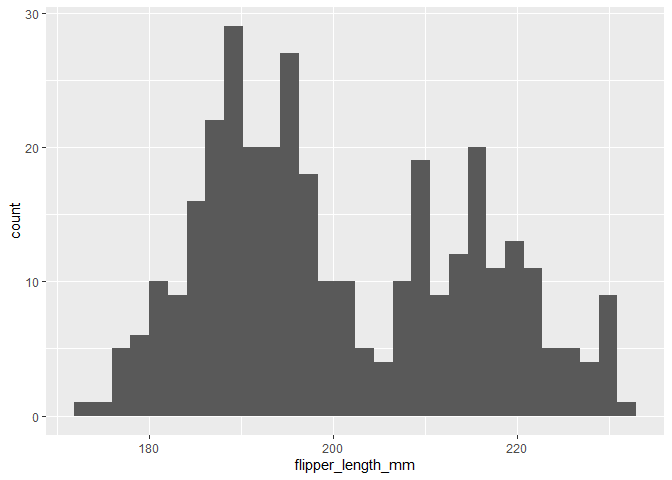

```r
ggplot(penguins) +
  geom_histogram(mapping = aes(x = flipper_length_mm))
```

This tells us there may be a lot of variation in flipper size among species. We can use the ‘fill =’ argument to color the bars by species, and `scale_fill_manual()` to specify the colors.

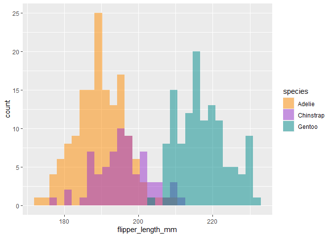

```r
# Histogram example: flipper length by species
ggplot(penguins) +
  geom_histogram(aes(x = flipper_length_mm, fill = species), alpha = 0.5, position = "identity") +
  scale_fill_manual(values = c("darkorange","darkorchid","cyan4"))
```

Cool, now we can see there seems to be some pretty clear variation in flipper size among species. Another way to visualize across groups is with `facet_wrap()`, which will create a separate plot for each group, in this case species.

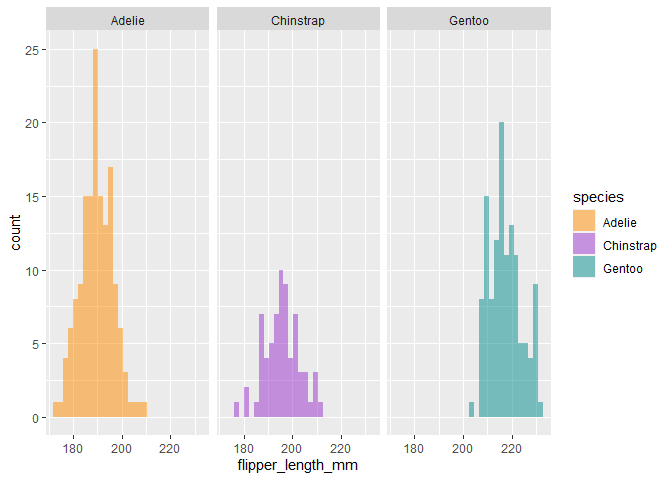

```r
ggplot(penguins) +
  geom_histogram(aes(x = flipper_length_mm, fill = species), alpha = 0.5, position = "identity") +
  scale_fill_manual(values = c("darkorange","darkorchid","cyan4")) +
  facet_wrap(~species)
```

Lets make a quick bar plot showing the total count of each species studied on each island

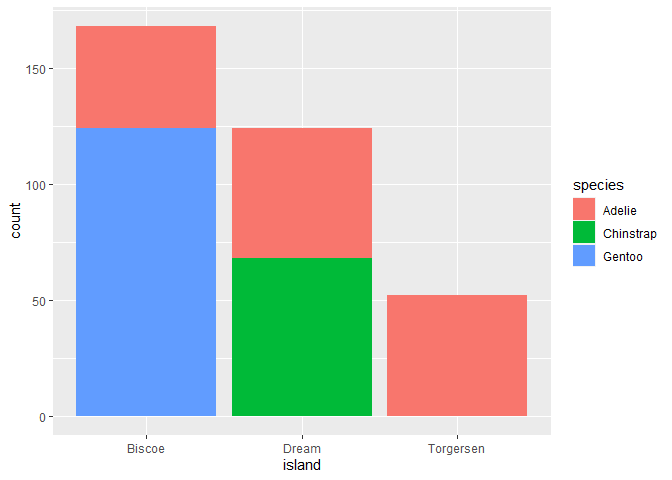

```r
ggplot(penguins) +
  geom_bar(mapping = aes(x = island, fill = species))
```

As you may have already noticed, the beauty about `ggplot2` is there are a million ways you can customize your plots. This example builds on our simple bar plot

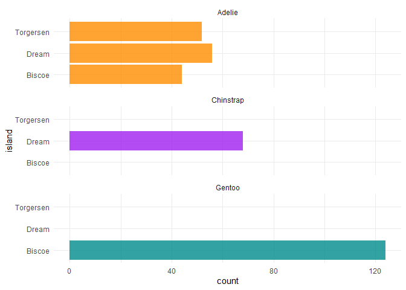

```r
ggplot(penguins, aes(x = island, fill = species)) +
  geom_bar(alpha = 0.8) +
  scale_fill_manual(values = c("darkorange","purple","cyan4"),
                    guide = FALSE) +
  theme_minimal() +
  facet_wrap(~species, ncol = 1) +
  coord_flip()
```

We can use `geom_point()` to view the relationship between two variables by specifying the x and y axes. Say we want to visualize the relationship between penguin body mass and flipper length and color the point by species:

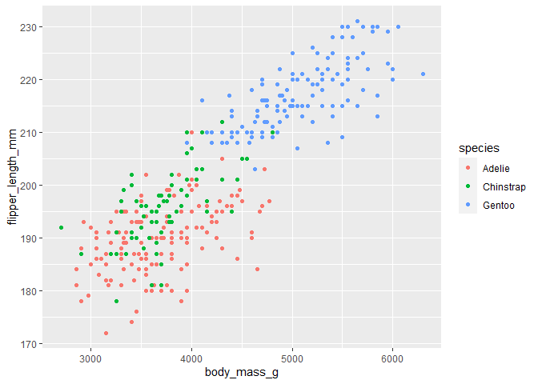

```r
ggplot(penguins) +
  geom_point(mapping = aes(x = body_mass_g, y = flipper_length_mm, color = species))
```

### 7.1 Exercises

1. Make a barplot showing the average flipper length for each species.

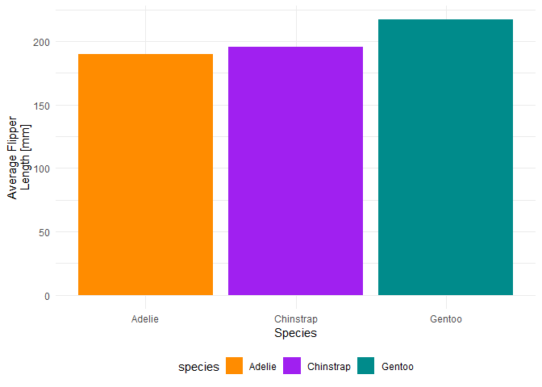

```r
penguins_mean_flip <- penguins %>%
  group_by(species) %>%
  summarize(avg_flipper_length_mm = mean(flipper_length_mm, na.rm = TRUE))


ggplot(data = penguins %>% group_by(species) %>% summarize(avg_flipper_length_mm = mean(flipper_length_mm, na.rm = TRUE)), aes(y = avg_flipper_length_mm, x = species, fill = species)) +
  geom_bar(stat = "identity") +
  scale_fill_manual(values = c("darkorange","purple","cyan4")) +
  labs(x = "Species", y = "Average Flipper\nLength [mm]") +
  theme_minimal() + theme(legend.position = "bottom")
```

2. Make a scatter plot of bill length compared to bill depth but only for observations on the Dream island.

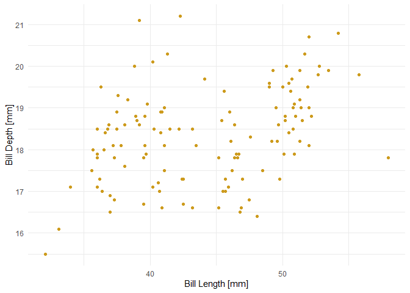

```r
ggplot(data = penguins %>% filter(island == "Dream"), mapping = aes(x = bill_length_mm, y = bill_depth_mm)) +
  geom_point(color = "goldenrod3") +
  theme_minimal() +
  labs(x = "Bill Length [mm]", y = "Bill Depth [mm]")
```

## 8. Read and Write Data

We used an R data package today to read in our data frame, but that probably isn’t how you will normally read in your data.

There are many ways to read and write data in R. To read in .csv files, you can use `read_csv()` which is included in the Tidyverse with the `readr` package, and to save csv files use `write_csv()`. The `readxl` package is great for reading in excel files, however it is not included in the Tidyverse and will need to be loaded separately.